# 12_PredictionIntervals_Transformations

Author

Prof. Juan Garbayo

# References

NOTE: this notebook adapts reference 1 for the classes.

1. Hyndman, R.J., & Athanasopoulos, G., 2021. *Forecasting: principles and practice*. 3rd edition.
2. Fable package documentation
- https://fable.tidyverts.org/index.html
- https://fable.tidyverts.org/articles/fable.html
- https://fable.tidyverts.org/articles/transformations.html
- https://robjhyndman.com/hyndsight/backtransforming/
- https://robjhyndman.com/hyndsight/forecasting-within-limits/
3. [Forecast estimation, evaluation and transformation](https://robjhyndman.com/hyndsight/forecastmse/)

# Packages

```r
library(fpp3)
library(patchwork) # to place two plots side by side with p1 + p2
```

# Reminder from Session 8: point forecasts and forecast distributions

**$y_t$**: the random variable to be forecast. The subscript $t$ indicates the observation at time $t$.

**Prediction interval, or interval forecast**: a range of values within which $y_t$ falls with a given probability.

Let us see an example with the data below: the trend of international arrivals to Australia, with the seasonality removed.

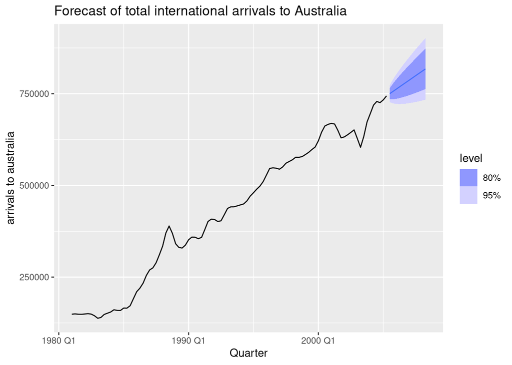

Let us now focus only on the forecast region. The figure below shows the forecast with its 80% and 95% prediction intervals at the top, and the forecast distribution at each quarter below. There is one distribution per quarter, because the data is quarterly.

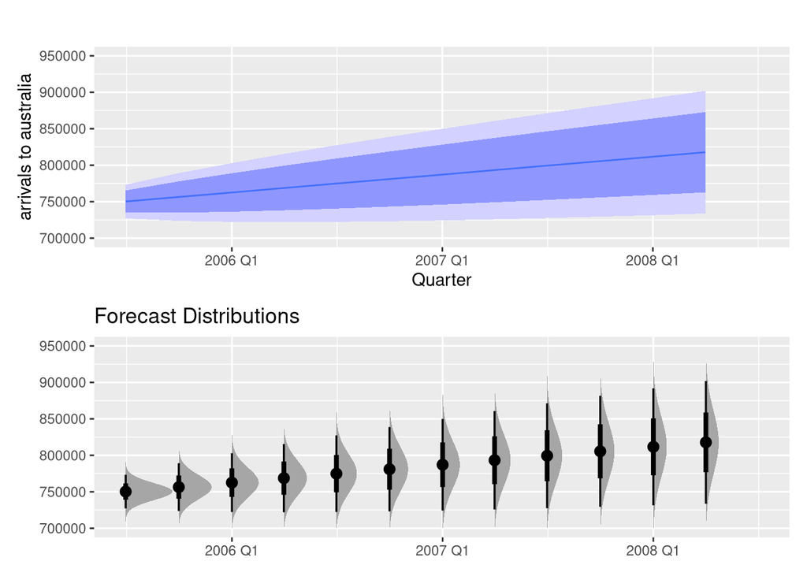

Recall from the session on benchmark models that the **point forecast is the mean of the forecast distribution.**

# Forecast distributions

Most time series models produce **normally distributed forecasts**.

## Prediction intervals

- An interval within which we expect $y_t$ to lie with a specified probability.
- Assuming a normal forecast distribution, a two-sided prediction interval for the forecast is:

$$\hat{y}_{T+h|T} \pm c \hat\sigma_h,$$

where:

- $\hat\sigma_h$ is an estimate of the standard deviation of the $h$-step forecast distribution.
- the multiplier $c$ depends on the **coverage probability** and is equal to the corresponding quantile of the standard normal distribution $N(0,1)$. Usually we will compute 80% and 95% intervals, although another coverage may be used.

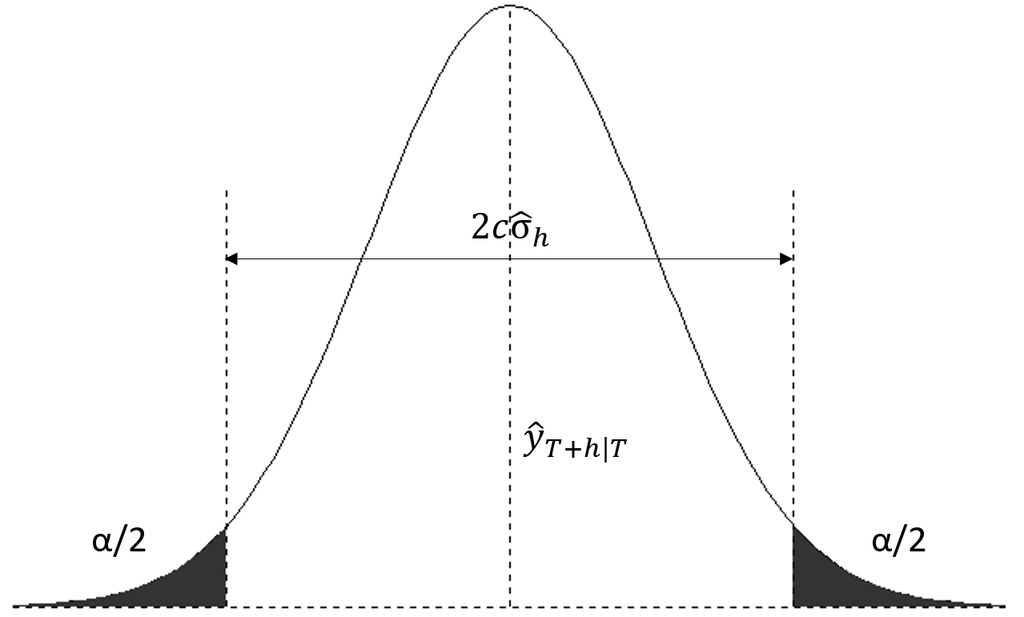

Forecast prediction intervals computed from point forecast assuming normal forecast distribution

std. normal quantiles

| alpha | percentage | coefficient `c` |
| --- | --- | --- |
| 0.50 | 0.50 | 0.67 |
| 0.45 | 0.55 | 0.76 |
| 0.40 | 0.60 | 0.84 |
| 0.35 | 0.65 | 0.93 |
| 0.30 | 0.70 | 1.04 |
| 0.25 | 0.75 | 1.15 |
| 0.20 | 0.80 | 1.28 |
| 0.15 | 0.85 | 1.44 |
| 0.10 | 0.90 | 1.64 |
| 0.05 | 0.95 | 1.96 |
| 0.04 | 0.96 | 2.05 |
| 0.03 | 0.97 | 2.17 |
| 0.02 | 0.98 | 2.33 |
| 0.01 | 0.99 | 2.58 |

### Intervals for one-step forecasts

When forecasting **one step ahead** ($h=1$), the standard deviation of the forecast distribution can be estimated with the standard deviation of the residuals. Residuals are, after all, the errors of one-step-ahead forecasts on the training data, so they estimate $\sigma_1$, the sigma for $h=1$.

$$\hat{\sigma_1} = \sqrt{\frac{1}{T-K}\sum_{t=1}^T e_t^2}$$

- $T$ is the length of the residuals (after removing NAs).
- $K$ is the number of parameters of the particular model being fitted.

### Intervals for multi-step forecasts

Prediction intervals usually widen as the forecast horizon grows. The further ahead we forecast, the more uncertain the forecast, and the wider the interval.

#### Explicit formulas for the multi-step forecast variance

For some methods, the benchmark methods among them, the multi-step forecast variance has an explicit formula. Deriving these formulas is not part of this course, and not every method has such a simple formula. Some examples:

| Benchmark method | h-step forecast standard deviation |
| --- | --- |
| Mean | $\hat{\sigma}_h=\hat{\sigma}\sqrt{1+1/T}$ |
| Naïve | $\hat{\sigma}_h=\hat{\sigma}\sqrt{h}$ |
| Seasonal naïve | $\hat{\sigma}_h=\hat{\sigma}\sqrt{k+1}$ |
| Drift | $\hat{\sigma}_h=\hat{\sigma}\sqrt{h(1+h/T)}$ |

- $T$ is the length of the residuals (after removing NAs).
- $h$ is the forecast horizon.
- $\hat\sigma$ is the standard deviation of the residuals, the one-step estimate above.
- $k$ is the integer part of $(h-1)/m$, where $m$ is the seasonal period.
  - in other words, $k$ is the number of complete seasonal periods in the forecast prior to time $T+h$

For other models, the formulas become more complex.

#### A more general approach: bootstrapped residuals

The prediction intervals returned by the `fable` package can be trusted as long as the residuals are normal and have constant variance.

When this is not the case, we may resort to [**bootstrapping**](https://otexts.com/fpp3/prediction-intervals.html#prediction-intervals-from-bootstrapped-residuals) to obtain the multi-step forecast variances of a given method. This assumes **uncorrelated residuals with constant variance**, but not normal ones.

### Computing prediction intervals with the fable package

Let us go through a practical example of how to handle the prediction intervals that `fable` returns.

```r
google_stock <- gafa_stock |>
  filter(Symbol == "GOOG", year(Date) >= 2015) |>

  # Create regularly spaced time index `day`
  # since trading days are not evenly distributed.
  mutate(day = row_number()) |>
  update_tsibble(index = day, regular = TRUE)

google_2015 <- google_stock |> filter(year(Date) == 2015) |>
                  select(Symbol, Date, day, Close)

head(google_2015)
```

```
# A tsibble: 6 x 4 [1]
# Key:       Symbol [1]
  Symbol Date         day Close
  <chr>  <date>     <int> <dbl>
1 GOOG   2015-01-02     1  522.
2 GOOG   2015-01-05     2  511.
3 GOOG   2015-01-06     3  499.
4 GOOG   2015-01-07     4  498.
5 GOOG   2015-01-08     5  500.
6 GOOG   2015-01-09     6  493.
```

#### `hilo()` computes the prediction intervals

The function `hilo()` computes the prediction intervals from the forecast distributions. Without arguments, it computes the `80%` and `95%` intervals.

```r
horiz = 5

google_stock <- gafa_stock |>
  filter(Symbol == "GOOG", year(Date) >= 2015) |>
  mutate(day = row_number()) |>
  update_tsibble(index = day, regular = TRUE)

google_2015 <- google_stock |> filter(year(Date) == 2015)

fit <- google_2015 |>
        model(NAIVE(Close))

fc <- fit |>
        forecast(h = horiz)

fc_hilo <- fc |> hilo()
fc_hilo
```

```
# A tsibble: 5 x 7 [1]
# Key:       Symbol, .model [1]
  Symbol .model         day
  <chr>  <chr>        <dbl>
1 GOOG   NAIVE(Close)   253
2 GOOG   NAIVE(Close)   254
3 GOOG   NAIVE(Close)   255
4 GOOG   NAIVE(Close)   256
5 GOOG   NAIVE(Close)   257
# ℹ 4 more variables: Close <dist>, .mean <dbl>, `80%` <hilo>, `95%` <hilo>
```

#### Inspecting the prediction intervals

There are two ways to extract the limits of the intervals computed by `hilo()`:

1. (Not recommended) extract one element of the vector of intervals:

```r
# Vector of 80% prediction intervals
pints_80 <- fc_hilo |> pull(`80%`)
pints_80[1]
```

```
<hilo[1]>
[1] [744.54, 773.22]80
```

Then we can access the components `lower`, `upper` and `level` using the `$` operator:

```r
pints_80[1]$lower # Lower bound of the prediction interval
```

```
[1] 744.54
```

```r
pints_80[1]$upper # Upper bound of the prediction interval
```

```
[1] 773.22
```

```r
pints_80[1]$level # Coverage level
```

```
[1] 80
```

2. Use `unpack_hilo()` to create new columns with the limits of the intervals: `*_lower` and `*_upper` for each interval unpacked. Remember that the column `.mean` of the forecast table is the mean of the forecast distribution.

```r
fc_hilo <- fc_hilo |>
  unpack_hilo(c(`80%`, `95%`))

fc_hilo |>
  select(day, .mean, `80%_upper`, `80%_lower`, `95%_lower`, `95%_upper`)
```

```
# A tsibble: 5 x 6 [1]
    day .mean `80%_upper` `80%_lower` `95%_lower` `95%_upper`
  <dbl> <dbl>       <dbl>       <dbl>       <dbl>       <dbl>
1   253  759.        773.        745.        737.        781.
2   254  759.        779.        739.        728.        790.
3   255  759.        784.        734.        721.        797.
4   256  759.        788.        730.        715.        803.
5   257  759.        791.        727.        710.        808.
```

#### Check: the mean of the forecast distribution (the point forecast) is the center of the prediction interval

Importantly, **if the forecast distribution is symmetric**, the mean and the median will coincide. And remember that the point forecast is computed as the mean of the forecast distribution (column `.mean` of the fable):

```r
# Compute the midpoints of the prediction intervals
midpoints <- fc_hilo |>
  mutate(midpoints = (`95%_lower` + `95%_upper`)*0.5) |> # Compute the midpoints of the 95% intervals
  pull(midpoints)

# Check that the column .mean is the midpoint of the intervals
all.equal(midpoints, fc_hilo$`.mean`)
```

```
[1] TRUE
```

#### Plotting prediction intervals

When plotting forecasts, `autoplot()` draws the 80% and 95% prediction intervals by default. Set `level = NULL` to leave them out.

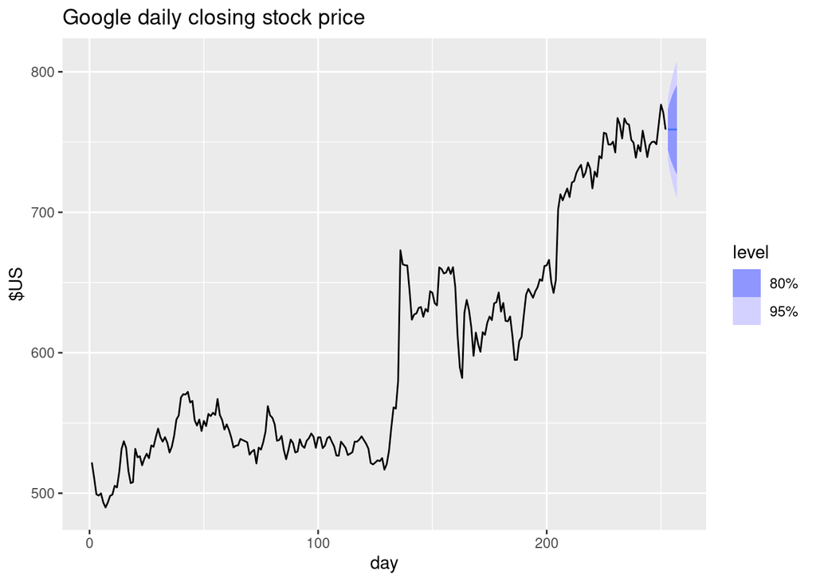

```r
fc |>
  autoplot(google_2015) +
  labs(title="Google daily closing stock price", y="$US" )
```

Again, let us zoom in on the forecast region. The figure below shows the point forecast (blue line), the 80% and 95% prediction intervals (shaded blue regions), and the forecast distributions underneath. The model generates normal forecast distributions.

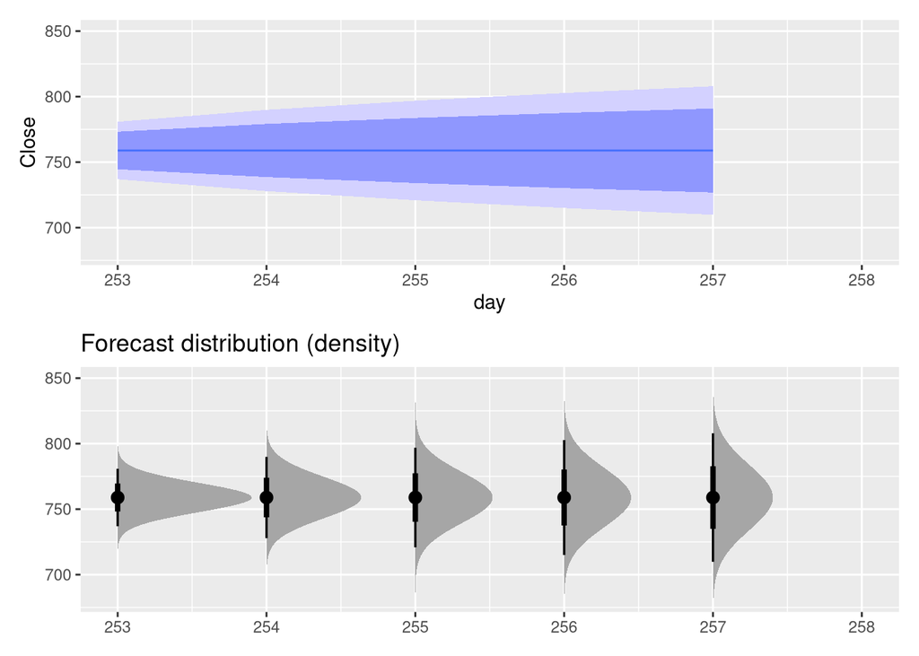

#### Extracting the parameters of the forecast distributions

By now you will have noticed that a forecast table has a column of type `<dist>`. It holds the forecast distribution at each horizon, and it always carries the name of the response variable, in this case `Close`.

```r
fc |> select(day, Close)
```

```
# A fable: 5 x 2 [1]
    day       Close
  <dbl>      <dist>
1   253 N(759, 125)
2   254 N(759, 250)
3   255 N(759, 376)
4   256 N(759, 501)
5   257 N(759, 626)
```

The function `parameters()` from the `distributional` package returns the parameters of each distribution. The package is installed with `fpp3`; here we call the function with `::` instead of loading the package.

```r
fc |> pull(Close) |> distributional::parameters()
```

```
      mu    sigma
1 758.88 11.18958
2 758.88 15.82446
3 758.88 19.38093
4 758.88 22.37917
5 758.88 25.02067
```

#### Check: manual computation of a prediction interval vs `hilo()`

As an example, let us compute by hand the 95% prediction interval for the 1-step forecast of the example above (Google stock prices, 2015).

We noted before that, **for a 1-step-ahead interval, the standard deviation of the forecast distribution can be estimated from the standard deviation of the residuals**:

$$\hat{\sigma} = \sqrt{\frac{1}{T-K}\sum_{t=1}^T e_t^2}$$

- $T$ is the length of the residuals (after removing NAs).
- $K$ is the number of parameters of the particular model being fitted

Using the formula above:

```r
# Extract the residuals
res <- fit |> augment() |> pull(.innov)
# Remove missing values before computing the length
res <- res[!is.na(res)]

# Compute T and K
T = length(res) # T number of points in the residuals
K = nrow(tidy(fit)) # K number of parameters in our model. 0 for NAIVE model.

sigma_res = sqrt(sum(res^2, na.rm=TRUE)/(T-K))

# Check whether our result matches the std. deviation of the forecast distribution
sigma_res
```

```
[1] 11.18958
```

```r
# Check that the standard deviation matches the fable computation
all.equal(sigma_res, distributional::parameters(fc$Close[1])$sigma)
```

```
[1] TRUE
```

With this we can compute the prediction interval around the point forecast (the mean of the forecast distribution), applying the formula:

$$\hat{y}_{T+h|T} \pm c \hat\sigma_h,$$

where:

- $\hat\sigma_h$ is an estimate of the standard deviation of the $h$-step forecast distribution.
- the multiplier $c$ depends on the **coverage probability** and is equal to the corresponding quantile of the normal distribution. Usually we will compute 80% and 95% intervals, although another coverage may be used.

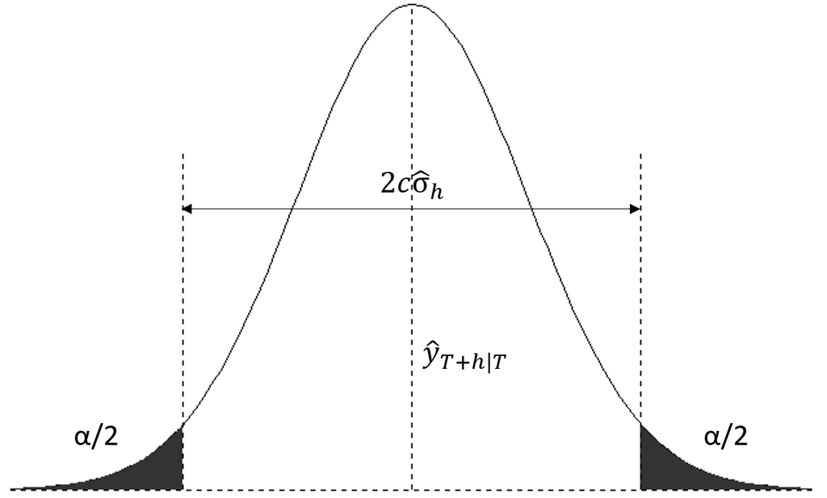

Forecast prediction intervals computed from point forecast assuming normal forecast distribution

For a 95% prediction interval we need the quantile at $1-0.05/2 = 97.5\%$ of the standard normal distribution (see the table at the beginning of this notebook).

```r
# Point forecast, which in this case is the mean of the forecast distribution
y_hat <- fc$.mean[1]

# Quantile of the normal distribution
alpha = 0.05 # 95% prediction interval
quant = qnorm(1-alpha*0.5, 0, 1)

# Prediction interval computed by hand
PI <- c(y_hat - quant*sigma_res, y_hat + quant*sigma_res)

# Prediction interval computed by fable
PI_hilo <- c(fc_hilo$`95%_lower`[1], fc_hilo$`95%_upper`[1])

# The interval computed by hand
PI
```

```
[1] 736.9488 780.8112
```

```r
# Check that it matches the one returned by fable
all.equal(PI, PI_hilo)
```

```
[1] TRUE
```

To compute intervals beyond a horizon of 1, we need an estimate of the standard deviation of the forecast distribution at that horizon. As noted earlier, explicit formulas exist for the benchmark methods (Mean, Naive, SNaive and Drift). For more complex methods there is no such general formula, but each method has its own computational approach. As long as the residuals are uncorrelated and normal, with constant variance, the returned intervals are reasonable.

Prediction intervals can also be computed from bootstrapped residuals, as noted earlier. That assumes uncorrelated residuals with constant variance, but not normal ones.

# Forecasting and transformations

When the data has been transformed:

1. The forecasts are produced on the transformed scale.
2. To obtain forecasts on the original scale, we need to **back-transform** them.

The Box-Cox transformation has an explicit inverse, so this could be done by hand. But `fable`, like any good forecasting software, does it for you:

$$\text{back-transform of box-cox: } \ \ \ \ y_{t} =
\begin{cases}
\exp(w_{t}) & \text{if $\lambda=0$};\\
\text{sign}(\lambda w_t+1)|\lambda w_t+1|^{1/\lambda} & \text{otherwise}.
\end{cases}$$

The `fable` package **performs the back-transformation automatically if the transformation is part of the model definition**.

## Prediction intervals and transformations

The forecast distribution is also transformed when the transformation is reversed. Consider the figure below:

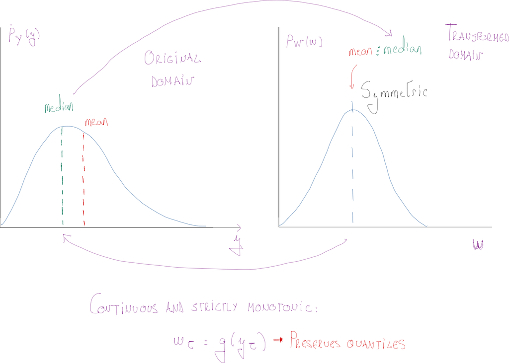

The transformation is meant to even out the spread of the data, which should give symmetrically distributed errors, as in the distribution on the right of the image (the transformed scale).

The forecast distribution inherits this symmetry: it is symmetric on the transformed scale ($w_t$), like the error distribution. But once it is brought back to the original scale, to give forecasts of $y_t$, it is no longer symmetric. Because the Box-Cox transformation is continuous and strictly monotonic, the quantiles are preserved: the probability coverage of any interval on the transformed scale survives the back-transformation to the original scale.

- The end points of the prediction intervals in the transformed domain are back-transformed to give a prediction interval on the original scale. This preserves the **probability coverage** of the prediction interval, but the prediction interval will no longer be symmetric around the point forecast. In other words, the back-transformed forecast will in general not be the mean of the forecast distribution.
- If the forecast distribution in the transformed space is symmetric, the back-transformed forecast will be the **median** of the forecast distribution in the original domain (original variables).
- The difference between the back-transformed forecast and the mean is called the **bias**. When using the mean rather than the median, we say the point forecasts have been **bias-adjusted**.
  - Using the median may be acceptable in many forecasting situations.
  - Some situations require properties of the mean that the median does not share, and you may need to recover the mean.
    - For example, adding sales forecasts for various regions requires the mean of the forecast distribution rather than the median, because **medians do not add up**.
    - For example, forecasting a number of related products requires the point forecasts to sum to give the forecast of the total number of products.
  - The larger the forecast variance, the larger the difference between the mean and the median. This follows from the formulas below, which approximate the **back-transformed mean on the original scale**. In them, $\hat{w}_{T+h|T}$ is the $h$-step forecast mean and $\sigma_h^2$ the $h$-step forecast variance, **both on the transformed scale**:

$$\hat{y}_{T+h|T} =
\begin{cases}
\exp(\hat{w}_{T+h|T})\left[1 + \frac{\sigma_h^2}{2}\right] & \text{if $\lambda=0$;}\\
(\lambda \hat{w}_{T+h|T}+1)^{1/\lambda}\left[1 + \frac{\sigma_h^2(1-\lambda)}{2(\lambda \hat{w}_{T+h|T}+1)^{2}}\right] & \text{otherwise;}
\end{cases}$$

The back-transformation that `fable` performs automatically does two things:

1. Forecasts come back on the original scale rather than the transformed one, provided the transformation was declared in the model definition.
2. Forecast medians are converted into forecast means (bias-adjusted).

The following example illustrates three important points:

1. The log transformation is applied in the model definition rather than before it, so that `fable` can back-transform automatically. That is, so that the package **knows** there is a transformation involved.
2. The code that asks `fable` to draw both the mean and the median point forecasts of the back-transformed distributions.
3. Most importantly, the back-transformed forecast distribution is **not symmetric**. The mean and the median differ, and neither sits at the midpoint of the interval.

```r
# Create a new column to hold the transformed variable
prices <- prices |>
  mutate(log_eggs = log(eggs))
```

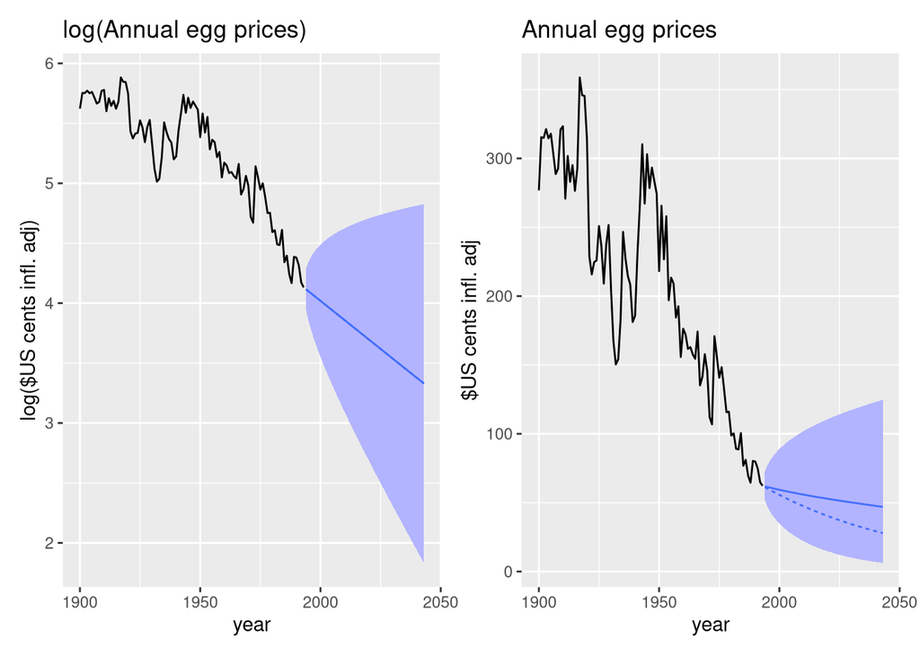

```r
# forecast horizon
horiz = 50

# Model 1: fitted to the variable already transformed
fit1 <- prices |>
  filter(!is.na(eggs)) |>
  model(drift = RW(log_eggs ~ drift()))

# fc1: forecasts generated with model 1
fc1 <- fit1 |>
  forecast(h = horiz)

# Model 2: fitted to the original variable specifying the transformation upon model definition
fit2 <- prices |>
  filter(!is.na(eggs)) |> # This line simply selects values that are not NAs from the time series
  model(RW(log(eggs) ~ drift()))

# fc2: forecasts generated with model 2
fc2 <- fit2 |>
  forecast(h = horiz)

# figures for each model
fig1 <- fc1 |>
  autoplot(prices |> filter(!is.na(eggs)),
           level = 80, point_forecast = lst(mean, median) # Depict both mean and median in the back transformed forecasts
           ) +
  labs(title = "log(Annual egg prices)",
       y = "log($US cents infl. adj)") +
  theme(legend.position="none") # Remove legend for mean and median to have more space for the plots

fig2 <- fc2 |>
  autoplot(prices |> filter(!is.na(eggs)),
           level = 80, point_forecast = lst(mean, median) # Depict both mean and median in the back transformed forecasts
           ) +
  labs(title = "Annual egg prices",
       y = "$US cents infl. adj") +
  theme(legend.position="none") # Remove legend for mean and median to have more space for the plots

fig1 + fig2
```

In the above graph:

- The right side shows the series and the forecasts on the original scale, once everything has been back-transformed. The mean of the forecast distribution is the solid line, the median the dashed one. The further into the future, the further apart they are. These forecast distributions are clearly not symmetric.
- The left side shows the series and the forecasts on the transformed scale. The mean and the median coincide: the forecast distribution on the transformed scale is symmetric. The symmetry is lost when back-transforming.

The figure below focuses on the forecast region and shows the forecast distributions on the transformed scale (left) and on the original scale (right), to make the loss of symmetry plain.

- Remember that the coverage of a prediction interval computed on the transformed scale is preserved when back-transforming, because the transformation is strictly monotonic. The difference is that, on the original scale, the interval is no longer symmetric around the mean of the forecast distribution.

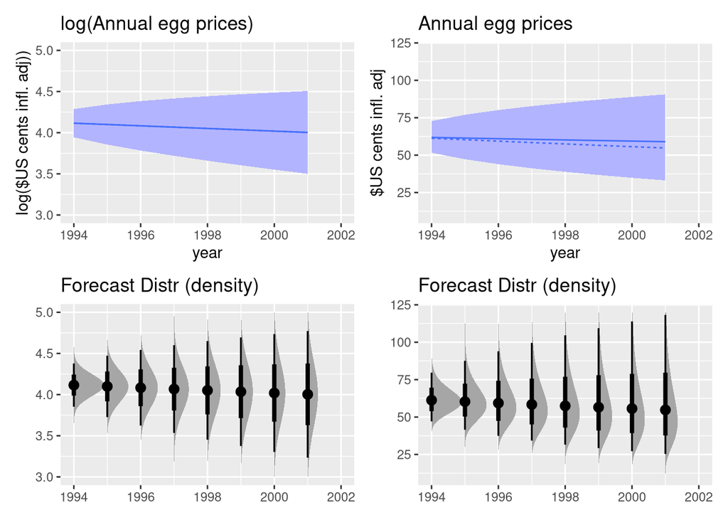

#### Understanding the forecasts returned when using transformations

Remember that, in the previous example, we have fitted two models:

- **Model 1**: fitted to the transformed variable `log_eggs = log(eggs)`

```r
# Model 1: fitted to the variable already transformed
fit1 <- prices |>
  filter(!is.na(eggs)) |>
  model(drift = RW(log_eggs ~ drift()))
```

- **Model 2**: fitted to the original variable, with the transformation declared in the model definition:

```r
# Model 2: fitted to the original variable specifying the transformation upon model definition
fit2 <- prices |>
  filter(!is.na(eggs)) |> # This line simply selects values that are not NAs from the time series
  model(RW(log(eggs) ~ drift()))
```

With those models we generated two forecast objects:

- `fc1`, from model 1. It returns forecasts on the transformed scale, because the model works on the transformed variable directly.

```r
head(fc1, 4)
```

```
# A fable: 4 x 4 [1Y]
# Key:     .model [1]
  .model  year      log_eggs
  <chr>  <dbl>        <dist>
1 drift   1994 N(4.1, 0.018)
2 drift   1995 N(4.1, 0.036)
3 drift   1996 N(4.1, 0.055)
4 drift   1997 N(4.1, 0.074)
# ℹ 1 more variable: .mean <dbl>
```

- `fc2`, from model 2. `fable` knows that model 2 has a transformation, so it back-transforms to the original scale and returns **bias-adjusted forecasts**: the column `.mean` is the mean of the back-transformed forecast distribution.

```r
head(fc2, 4)
```

```
# A fable: 4 x 4 [1Y]
# Key:     .model [1]
  .model                   year             eggs .mean
  <chr>                   <dbl>           <dist> <dbl>
1 RW(log(eggs) ~ drift())  1994 t(N(4.1, 0.018))  61.8
2 RW(log(eggs) ~ drift())  1995 t(N(4.1, 0.036))  61.4
3 RW(log(eggs) ~ drift())  1996 t(N(4.1, 0.055))  61.0
4 RW(log(eggs) ~ drift())  1997 t(N(4.1, 0.074))  60.6
```

#### Some checks on the forecasts and forecast distributions

##### Check 1: back-transforming the bounds of the intervals on the transformed scale gives the intervals on the original scale

```r
# Lower and upper bounds of the 80% and 95% prediction intervals
# on the transformed scale
fc1_intervals <-
  fc1 |>
    hilo() |>
    unpack_hilo(c(`80%`, `95%`))

# Lower and upper bounds of the 80% and 95% prediction intervals
# on the original scale
fc2_intervals <-
  fc2 |>
    hilo() |>
    unpack_hilo(c(`80%`, `95%`))

# Back-transform 95% lower bound
fc2_95lower_manual <- exp(fc1_intervals$`95%_lower`)
fc2_95lower_fable <- fc2_intervals$`95%_lower`

# Back-transform 95% upper bound
fc2_95upper_manual <- exp(fc1_intervals$`95%_upper`)
fc2_95upper_fable <- fc2_intervals$`95%_upper`

# CHECK
all.equal(fc2_95lower_manual, fc2_95lower_fable)
```

```
[1] TRUE
```

```r
all.equal(fc2_95upper_manual, fc2_95upper_fable)
```

```
[1] TRUE
```

##### Check 2: the mean on the transformed scale back-transforms to the median on the original scale

```r
# Back-transform the forecasts on the transformed scale (their mean)
fc1_backtransf <- exp(fc1$.mean)

# Compute medians of distributions of fc2
# fc2$eggs is a vector containing the forecast distributions of fc2
fc2_median <- median(fc2$eggs)

# CHECK
all.equal(fc1_backtransf, fc2_median)
```

```
[1] TRUE
```

##### Check 3: `fable` bias-adjusts the forecasts on the original scale, returning the mean of the back-transformed distribution

```r
# Compute the means of the distributions of fc2
fc2_mean_manual <- mean(fc2$eggs)

# Point forecasts (bias-adjusted)
fc2_point <- fc2$.mean

# CHECK
all.equal(fc2_mean_manual, fc2_point)
```

```
[1] TRUE
```

So `fable` returns bias-adjusted forecasts (the mean) automatically. If we want the median instead, we take the median of each forecast distribution. The following returns the median at every forecast horizon.

- NOTE: remember that the column `eggs` of the object fc2 holds the distribution objects.

```r
median(fc2$eggs)
```

```
 [1] 61.27912 60.30400 59.34441 58.40008 57.47078 56.55626 55.65630 54.77066
 [9] 53.89911 53.04143 52.19740 51.36680 50.54942 49.74504 48.95347 48.17449
[17] 47.40790 46.65352 45.91113 45.18056 44.46162 43.75412 43.05787 42.37271
[25] 41.69844 41.03491 40.38194 39.73935 39.10699 38.48470 37.87230 37.26965
[33] 36.67659 36.09297 35.51863 34.95344 34.39723 33.84988 33.31124 32.78117
[41] 32.25953 31.74620 31.24103 30.74390 30.25469 29.77325 29.29948 28.83325
[49] 28.37443 27.92292
```

# Exercise 1

Use `decomposition_model()` with an STL decomposition and a log transformation to generate a 36-step forecast of the `retail_series` used in Exercise 1 of notebook `08_A`. Back-transform the result to the original scale and plot both the mean and the median point forecasts.

As in `08_A`, use a drift model for the seasonally adjusted data and a seasonal naive model for the seasonal component.

```r
retail_series <- aus_retail |>
  filter(`Series ID` == "A3349767W")
```

## We’ll discuss potential solutions during the live session.